# assignment1

poornimajoshi

9/24/2018

Importing the library packages

```r
library(data.table)
library(moments)
library(dplyr)
```

```r
library(corrplot)
```

Importing the dataset and printing it

```r
dt <- data.table(read.csv("adult.csv", header = TRUE))
print(head(dt))
```

```
##    age workclass fnlwgt    education education.num marital.status
## 1:  90         ?  77053      HS-grad             9        Widowed
## 2:  82   Private 132870      HS-grad             9        Widowed
## 3:  66         ? 186061 Some-college            10        Widowed
## 4:  54   Private 140359      7th-8th             4       Divorced
## 5:  41   Private 264663 Some-college            10      Separated
## 6:  34   Private 216864      HS-grad             9       Divorced
##           occupation  relationship  race    sex capital.gain capital.loss
## 1:                 ? Not-in-family White Female            0         4356
## 2:   Exec-managerial Not-in-family White Female            0         4356
## 3:                 ?     Unmarried Black Female            0         4356
## 4: Machine-op-inspct     Unmarried White Female            0         3900
## 5:    Prof-specialty     Own-child White Female            0         3900
## 6:     Other-service     Unmarried White Female            0         3770
##    hours.per.week native.country income
## 1:             40  United-States  <=50K
## 2:             18  United-States  <=50K
## 3:             40  United-States  <=50K
## 4:             40  United-States  <=50K
## 5:             40  United-States  <=50K
## 6:             45  United-States  <=50K
```

`1. Create a boxplot for age and capture the outliers in a new variable. Then determine the percentage of outliers in age using the length function.`

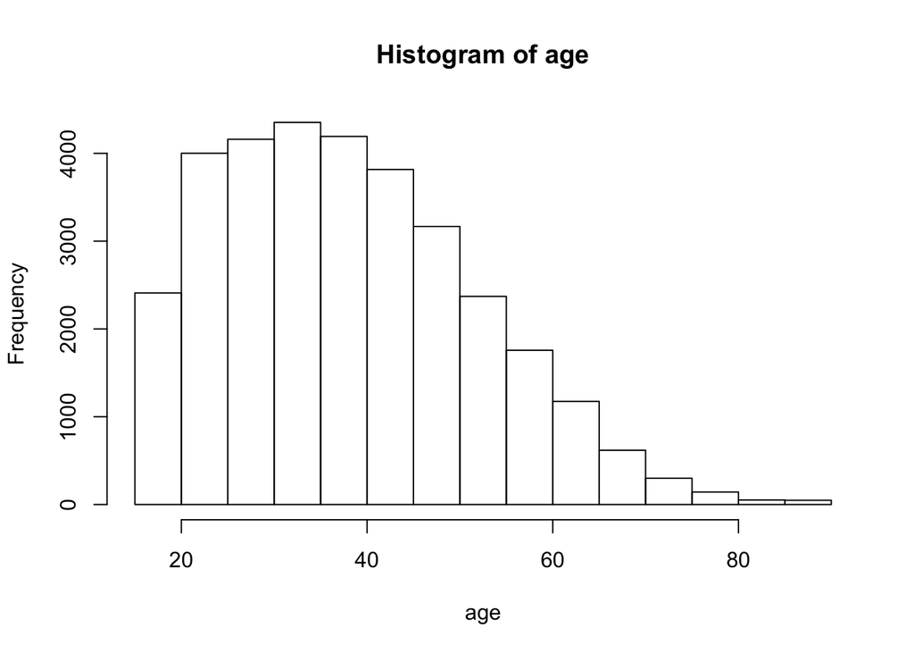

```r
age <- dt$age
education <- dt$education.num
hours_per_week <- dt$hours.per.week
hist(age)
```

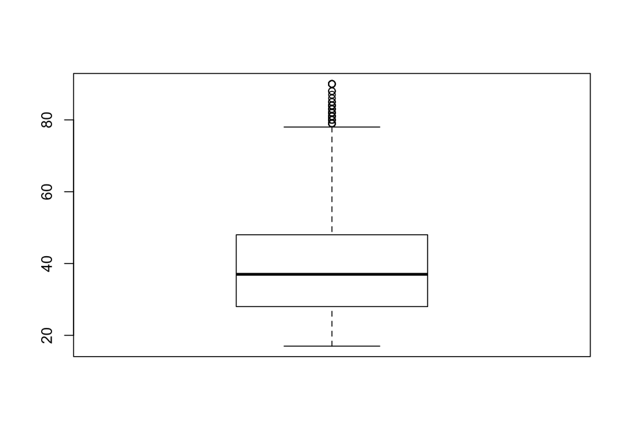

```r
bplot <- boxplot(age)
```

```r
outliers <- bplot$out
outliersperc <- (length(outliers)/length(age)) * 100
print(paste0("The outliers percentage in age is :", outliersperc))
```

```
## [1] "The outliers percentage in age is :0.439175700991984"
```

`2. Using the skewness function in the ???moments??? package/library determine whether the numeric variables are normally shaped. Above 1 or below -1 are considered not to be normal curves`

```r
dt[, sapply(dt, class) == "numeric"]
```

```
##            age      workclass         fnlwgt      education  education.num
##          FALSE          FALSE          FALSE          FALSE          FALSE
## marital.status     occupation   relationship           race            sex
##          FALSE          FALSE          FALSE          FALSE          FALSE
##   capital.gain   capital.loss hours.per.week native.country         income
##          FALSE          FALSE          FALSE          FALSE          FALSE
```

```r
new_dt <- dt[, lapply(dt, is.numeric) == TRUE, with = FALSE]
apply <-lapply(new_dt, function(x) (x - skewness(x)))
for(i in colnames(new_dt)){
skew <- skewness(new_dt[[i]])
if(skew > -1 & skew < 1) {
print(paste0(i, " is a normal curve with skew ", skew ))
}
}
```

```
## [1] "age is a normal curve with skew 0.558717629239857"
## [1] "education.num is a normal curve with skew -0.311661509635468"
## [1] "hours.per.week is a normal curve with skew 0.227632049774777"
```

`3. Create a new data.frame composed of only scaled numeric variables from the dataset called census_scaled_vars`

```r
dt[, sapply(dt, class) == "numeric"]
```

```
##            age      workclass         fnlwgt      education  education.num
##          FALSE          FALSE          FALSE          FALSE          FALSE
## marital.status     occupation   relationship           race            sex
##          FALSE          FALSE          FALSE          FALSE          FALSE
##   capital.gain   capital.loss hours.per.week native.country         income
##          FALSE          FALSE          FALSE          FALSE          FALSE
```

```r
new_dt <- dt[, lapply(dt, is.numeric) == TRUE, with = FALSE]
census_scaled_vars <- scale(new_dt)
```

`4. What are the percentiles and z scores for the following: a. Age ??? 80 b. Education number ??? 11 c. Hours per week - 40`

```r
percentile <- function(x, y) {
  pop_sd <- sd(x)*sqrt((length(x)-1)/(length(x)))
  pop_mean <- mean(x)
  z <- (y - pop_mean) / pop_sd
  percentile <- pnorm(z)
  print(paste0("The the percentile for age 80 is : ", percentile*100))
}

percentile(age, 80)
```

```
## [1] "The the percentile for age 80 is : 99.8803235857124"
```

```r
percentile(education, 11)
```

[output not shown]

```r
percentile(hours_per_week, 40)
```

[output not shown]

`5. Generate a corrplot using the data.frame/matrix from item 4 with the internal shapes being squares, include a title and only show the upper portion of the graphic.`

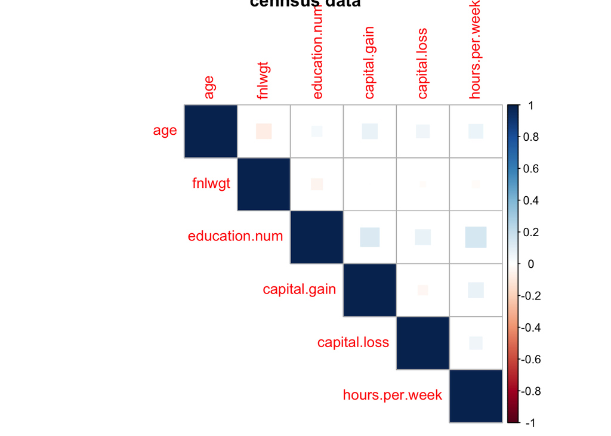

```r
corr <- cor(census_scaled_vars)
corrplot(corr, method="square", title="cennsus data", type="upper")
```

`6. What is the average hours worked per week, average capital gains and loss for each education group? Hint explore using dplyr and the summary function (We didn???t cover this in class, so just do the best you can)`

```r
dt %>%
  group_by(education) %>%
  summarise_at(vars(hours.per.week, capital.gain, capital.loss), funs(mean(., na.rm=TRUE)))
```

```
## # A tibble: 16 x 4
##    education    hours.per.week capital.gain capital.loss
##    <fct>                 <dbl>        <dbl>        <dbl>
##  1 10th                   37.1         405.         56.8
##  2 11th                   33.9         215.         50.1
##  3 12th                   35.8         284.         32.3
##  4 1st-4th                38.3         126.         48.3
##  5 5th-6th                38.9         176.         68.3
##  6 7th-8th                39.4         234.         65.7
##  7 9th                    38.0         342.         29.0
##  8 Assoc-acdm             40.5         640.         93.4
##  9 Assoc-voc              41.6         715.         72.8
## 10 Bachelors              42.6        1756.        118.
## 11 Doctorate              47.0        4770.        263.
## 12 HS-grad                40.6         577.         70.5
## 13 Masters                43.8        2563.        167.
## 14 Preschool              36.6         898.         66.5
## 15 Prof-school            47.4       10414.        231.
## 16 Some-college           38.9         599.         71.6
```